# Analysis

```python
import numpy as np
import pandas as pd
import matplotlib.pyplot as plt
import seaborn as sns
import os
%matplotlib inline
```

```python
import matplotlib.style as style
style.use('ggplot')

# Where to save the figures
PROJECT_ROOT_DIR = "."
CHAPTER_ID = "classification"

def save_fig(fig_id, tight_layout=True):
    path = os.path.join(fig_id + ".png")
    print("Saving figure", fig_id)
    if tight_layout:
        plt.tight_layout()
    plt.savefig(path, format='png', dpi=300)
```

```python
original_results = pd.read_excel('Anonymous Results Original.xlsx')
original_results.head()
```

|  | Are you an eCommerce store owner or were you in the past 12 months? | Which model best describes your store type? | How many years have you been involved in eCommerce? | Excluding yourself, how many payrolled employees do you have? | How many contractors do you use in your business? | What category of products do you sell? | How many different SKUs do you sell? | How old are you? | What is your gender? | How much do you struggle maintaining a work/life balance? | ... | What is your net worth excluding your eCommerce business' value? (Net worth: Value of all your assets minus debts) | Approximately what % of your net worth (excluding business value) is invested in the stock market? | Approximately what % of your net worth (excluding business value) is in cash? | Approximately what % of your net worth (excluding business value) is invested in real estate? | How much do you enjoy running / owning your business? | How hopeful are you for the future prospects of your business? | How happy overall would you say you are in life? | What’s the biggest struggle you’re facing right now in your business? | Are you a member of the eCommerceFuel Private Forum Community? | How would you rate the eCommerceFuel Private Community? |
| --- | --- | --- | --- | --- | --- | --- | --- | --- | --- | --- | --- | --- | --- | --- | --- | --- | --- | --- | --- | --- | --- |
| 0 | No | NaN | NaN | NaN | NaN | NaN | NaN | NaN | NaN | NaN | ... | NaN | NaN | NaN | NaN | NaN | NaN | NaN | NaN | NaN | NaN |
| 1 | Yes | Hybrid Model | 3 | 5-10 | 10-20 | Food | 0-9 | 19-29 | Male | 8.0 | ... | $500K-$999K | 40% | 60% | 0% | 8.0 | 9.0 | 7.0 | Hiring. | 1.0 | 8.0 |
| 2 | Yes | Manufacturing your own products/brand (Proprie... | 10 | 25+ | 2-5 | Food | 1000-4999 | 30-39 | Male | 8.0 | ... | $3 Mil - $4.9 Mil | 0% | 60% | 40% | 8.0 | 9.0 | 9.0 | Building a better management team. | 1.0 | 10.0 |
| 3 | Yes | Hybrid Model | 10-15 | 1 | 2-5 | Clothing and Accessories - Both Sexes | 1000-4999 | 40-49 | Female | 10.0 | ... | $100K-$249K | 0% | 10% | 0% | 7.0 | 10.0 | 3.0 | NaN | 1.0 | 9.0 |
| 4 | Yes | Selling your own brand of products (Private La... | 4 | 5-10 | 2-5 | Pets Supplies | 250-499 | 19-29 | Male | 6.0 | ... | $100K-$249K | 10% | 70% | 0% | 9.0 | 9.0 | 8.0 | Scaling website customer acquisition | 1.0 | 9.0 |

5 rows × 44 columns

```python
original_results['Are you an eCommerce store owner or were you in the past 12 months?'].value_counts()
```

```
Yes    463
No      63
Name: Are you an eCommerce store owner or were you in the past 12 months?, dtype: int64
```

```python
original_results = original_results[original_results['Are you an eCommerce store owner or were you in the past 12 months?'] == 'Yes']
original_results.describe()
```

|  | How much do you struggle maintaining a work/life balance? | Does your business provide a full-time income? Or, if you’re still working a job, could it? | What is your average order value (AOV)? Please enter WITHOUT a "$" or currency sign. | Apart from Amazon, do you use a 3PL or fulfillment company to fulfill your orders? | Do you use your home as your primary office / work space? | How much do you enjoy running / owning your business? | How hopeful are you for the future prospects of your business? | How happy overall would you say you are in life? | Are you a member of the eCommerceFuel Private Forum Community? | How would you rate the eCommerceFuel Private Community? |
| --- | --- | --- | --- | --- | --- | --- | --- | --- | --- | --- |
| count | 461.000000 | 458.000000 | 458.000000 | 459.000000 | 459.000000 | 459.000000 | 459.000000 | 458.000000 | 459.000000 | 290.000000 |
| mean | 5.462039 | 0.823144 | 308.727074 | 0.270153 | 0.527233 | 8.167756 | 8.193900 | 8.008734 | 0.631808 | 8.620690 |
| std | 2.622058 | 0.381964 | 2377.848889 | 0.444523 | 0.499803 | 1.598364 | 1.865419 | 1.486603 | 0.482840 | 1.424302 |
| min | 0.000000 | 0.000000 | 0.000000 | 0.000000 | 0.000000 | 2.000000 | 0.000000 | 3.000000 | 0.000000 | 3.000000 |
| 25% | 3.000000 | 1.000000 | 40.000000 | 0.000000 | 0.000000 | 7.000000 | 7.000000 | 7.000000 | 0.000000 | 8.000000 |
| 50% | 6.000000 | 1.000000 | 72.000000 | 0.000000 | 1.000000 | 8.000000 | 8.000000 | 8.000000 | 1.000000 | 9.000000 |
| 75% | 7.000000 | 1.000000 | 150.000000 | 1.000000 | 1.000000 | 9.500000 | 10.000000 | 9.000000 | 1.000000 | 10.000000 |
| max | 10.000000 | 1.000000 | 50000.000000 | 1.000000 | 1.000000 | 10.000000 | 10.000000 | 10.000000 | 1.000000 | 10.000000 |

### (Some quick graphs to test)

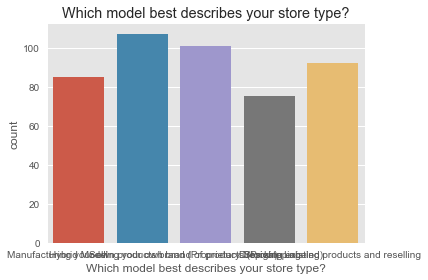

```python
ax = sns.countplot(data=original_results, x='Which model best describes your store type?', orient='v')
plt.title('Which model best describes your store type?')
#ax.set_xticklabels(['Manufacturing',''])
plt.tight_layout()
plt.savefig('test.png')
plt.show()
# ax.set
```

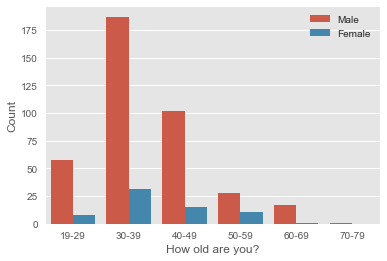

```python
sns_plot = sns.countplot(x='How old are you?', hue='What is your gender?', data=original_results)
plt.legend(loc='upper right')
plt.ylabel('Count')
plt.figure(figsize=(16,6))
sns_fig = sns_plot.get_figure()
sns_fig.savefig('age_by_gender')
```

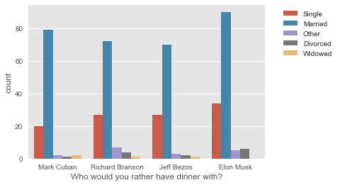

```python
sns.countplot(data=original_results, x='Who would you rather have dinner with?', hue='What\'s your marital status?')
plt.legend(bbox_to_anchor=(1.05, 1))
```

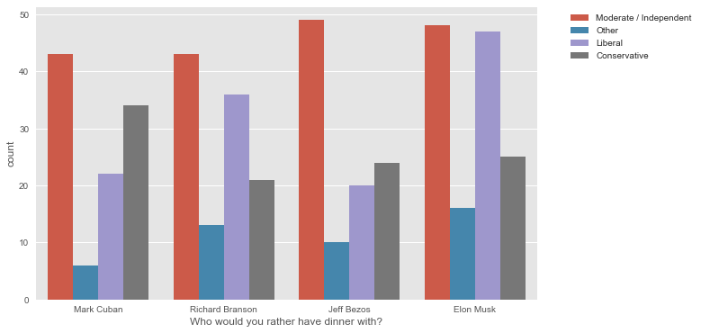

```python
fig, ax = plt.subplots(figsize=(10,6))
sns.countplot(ax=ax, data=original_results, x='Who would you rather have dinner with?', hue='Politically would you consider yourself:')
plt.savefig('dinner_by_political')
plt.legend(bbox_to_anchor=(1.05, 1))
```

# Data augmentation

```python
modified_results = original_results.copy()
modified_results
```

|  | Are you an eCommerce store owner or were you in the past 12 months? | Which model best describes your store type? | How many years have you been involved in eCommerce? | Excluding yourself, how many payrolled employees do you have? | How many contractors do you use in your business? | What category of products do you sell? | How many different SKUs do you sell? | How old are you? | What is your gender? | How much do you struggle maintaining a work/life balance? | ... | What is your net worth excluding your eCommerce business' value? (Net worth: Value of all your assets minus debts) | Approximately what % of your net worth (excluding business value) is invested in the stock market? | Approximately what % of your net worth (excluding business value) is in cash? | Approximately what % of your net worth (excluding business value) is invested in real estate? | How much do you enjoy running / owning your business? | How hopeful are you for the future prospects of your business? | How happy overall would you say you are in life? | What’s the biggest struggle you’re facing right now in your business? | Are you a member of the eCommerceFuel Private Forum Community? | How would you rate the eCommerceFuel Private Community? |
| --- | --- | --- | --- | --- | --- | --- | --- | --- | --- | --- | --- | --- | --- | --- | --- | --- | --- | --- | --- | --- | --- |
| 1 | Yes | Hybrid Model | 3 | 5-10 | 10-20 | Food | 0-9 | 19-29 | Male | 8.0 | ... | $500K-$999K | 40% | 60% | 0% | 8.0 | 9.0 | 7.0 | Hiring. | 1.0 | 8.0 |
| 2 | Yes | Manufacturing your own products/brand (Proprie... | 10 | 25+ | 2-5 | Food | 1000-4999 | 30-39 | Male | 8.0 | ... | $3 Mil - $4.9 Mil | 0% | 60% | 40% | 8.0 | 9.0 | 9.0 | Building a better management team. | 1.0 | 10.0 |
| 3 | Yes | Hybrid Model | 10-15 | 1 | 2-5 | Clothing and Accessories - Both Sexes | 1000-4999 | 40-49 | Female | 10.0 | ... | $100K-$249K | 0% | 10% | 0% | 7.0 | 10.0 | 3.0 | NaN | 1.0 | 9.0 |
| 4 | Yes | Selling your own brand of products (Private La... | 4 | 5-10 | 2-5 | Pets Supplies | 250-499 | 19-29 | Male | 6.0 | ... | $100K-$249K | 10% | 70% | 0% | 9.0 | 9.0 | 8.0 | Scaling website customer acquisition | 1.0 | 9.0 |
| 5 | Yes | Drop shipping | 2 | 1 | 2-5 | Health and Personal Care | 1000-4999 | 19-29 | Male | 9.0 | ... | $25-$99K | 50% | 50% | 0% | 6.0 | 7.0 | 6.0 | Data analysis | 1.0 | 9.0 |
| 6 | Yes | Hybrid Model | 8 | 2-5 | 2-5 | Toys and Games | 1000-4999 | 40-49 | Male | 1.0 | ... | $250K-$499K | 50% | 20% | 40% | 8.0 | 3.0 | 10.0 | Finding good talent to scale our marketing esp... | 1.0 | 10.0 |
| 7 | Yes | Selling your own brand of products (Private La... | 10-15 | 2-5 | 1 | Clothing and Accessories - Women | 250-499 | 40-49 | Male | 2.0 | ... | $3 Mil - $4.9 Mil | 10% | 70% | 20% | 7.0 | 7.0 | 9.0 | Boredom | 1.0 | 8.0 |
| 8 | Yes | Drop shipping | 4 | 0 | 2-5 | Home and Kitchen | 5000-9999 | 50-59 | Male | 7.0 | ... | $250K-$499K | 0% | 0% | 80% | 10.0 | 10.0 | 8.0 | Developing a private label product | 1.0 | 10.0 |
| 9 | Yes | Hybrid Model | 15-20 | 25+ | 2-5 | Pets Supplies | 5000-9999 | 30-39 | Male | 5.0 | ... | $25-$99K | 50% | 5% | 0% | 10.0 | 10.0 | 10.0 | Deciding which opportunities to pursue next (f... | 1.0 | 3.0 |
| 10 | Yes | Manufacturing your own products/brand (Proprie... | 6 | 5-10 | 1 | Toys and Games | 1000-4999 | 30-39 | Male | 4.0 | ... | $0-$24K | 5% | 0% | 80% | 8.0 | 6.0 | 7.0 | I am struggling to find the correct way to adv... | 1.0 | 8.0 |
| 11 | Yes | Selling your own brand of products (Private La... | 2 | 1 | 10-20 | Toys and Games | 0-9 | 30-39 | Male | 6.0 | ... | $250K-$499K | 20% | 20% | 20% | 10.0 | 8.0 | 10.0 | Introducing new products | 1.0 | 10.0 |
| 12 | Yes | Stocking existing products and reselling | 9 | 25+ | 2-5 | Patio, Lawn or Garden | 10,000-24,999 | 40-49 | Male | 5.0 | ... | $2.0 Mil - $2.9 Mil | 70% | 10% | 20% | 10.0 | 8.0 | 7.0 | Finding the right people | 1.0 | 5.0 |
| 13 | Yes | Manufacturing your own products/brand (Proprie... | 20+ | 10-20 | 1 | Arts and Crafts | 10-99 | 50-59 | Male | 5.0 | ... | $250K-$499K | 10% | 5% | 50% | 7.0 | 7.0 | 8.0 | Dependence on holiday seasonality | 1.0 | 9.0 |
| 14 | Yes | Hybrid Model | 5 | 5-10 | 0 | Clothing and Accessories - Women | 100-249 | 30-39 | Male | 8.0 | ... | $250K-$499K | 70% | 30% | 0% | 7.0 | 7.0 | 5.0 | Cash-flow issues that come with scaling. | 1.0 | 7.0 |
| 15 | Yes | Manufacturing your own products/brand (Proprie... | 4 | 5-10 | 0 | Clothing and Accessories - Men | 100-249 | 30-39 | Male | 8.0 | ... | $500K-$999K | 0% | 5% | 80% | 9.0 | 10.0 | 7.0 | Space - we're moving to a new location this mo... | 1.0 | 7.0 |
| 16 | Yes | Manufacturing your own products/brand (Proprie... | 15-20 | 2-5 | 0 | Clothing and Accessories - Both Sexes | 500-999 | 60-69 | Male | 4.0 | ... | $250K-$499K | 40% | 20% | 40% | 5.0 | 5.0 | 9.0 | Seasonal sales | 1.0 | 10.0 |
| 17 | Yes | Stocking existing products and reselling | 5 | 1 | 5-10 | Computers | 100-249 | 30-39 | Male | 1.0 | ... | $1 Mil - $1.9 Mil | 40% | 10% | 30% | 6.0 | 7.0 | 6.0 | keep it at a lifestyle business or go deep | 1.0 | 9.0 |
| 18 | Yes | Manufacturing your own products/brand (Proprie... | 3 | 1 | 2-5 | Furniture | 10-99 | 30-39 | Male | 6.0 | ... | $500K-$999K | 0% | 40% | 60% | 9.0 | 8.0 | 10.0 | Manufacturing | 1.0 | 5.0 |
| 19 | Yes | Stocking existing products and reselling | 5 | 5-10 | 2-5 | Sports and Outdoors | 5000-9999 | 30-39 | Female | 3.0 | ... | $250K-$499K | 0% | 5% | 90% | 9.0 | 9.0 | 10.0 | Which opportunity to pursue! | 1.0 | 10.0 |
| 20 | Yes | Selling your own brand of products (Private La... | 2 | 0 | 2-5 | Health and Personal Care | 0-9 | 19-29 | Male | 5.0 | ... | $0-$24K | 0% | 10% | 0% | 10.0 | 10.0 | 7.0 | Cash flow for product line expansion | 0.0 | NaN |
| 21 | Yes | Manufacturing your own products/brand (Proprie... | 6 | 2-5 | 1 | Clothing and Accessories - Both Sexes | 25,000+ | 30-39 | Male | 5.0 | ... | $250K-$499K | 30% | 5% | 60% | 5.0 | 8.0 | 7.0 | hiring | 1.0 | 10.0 |
| 22 | Yes | Selling your own brand of products (Private La... | 3 | 0 | 1 | Health and Personal Care | 10-99 | 30-39 | Male | 3.0 | ... | $100K-$249K | 70% | 20% | 0% | 7.0 | 3.0 | 8.0 | slowing amazon sales | 1.0 | 8.0 |
| 23 | Yes | Hybrid Model | 2 | 1 | 2-5 | Automotive | 250-499 | 19-29 | Male | 10.0 | ... | $100K-$249K | 50% | 50% | 0% | 10.0 | 6.0 | 9.0 | Too many ideas, not enough time or focus. | 1.0 | 10.0 |
| 24 | Yes | Stocking existing products and reselling | 3 | 2-5 | 2-5 | Arts and Crafts | 10-99 | 30-39 | Male | 6.0 | ... | $500K-$999K | 40% | 5% | 50% | 8.0 | 8.0 | 7.0 | Sustained and profitable growth | 1.0 | 8.0 |
| 25 | Yes | NaN | NaN | NaN | NaN | NaN | NaN | NaN | NaN | NaN | ... | NaN | NaN | NaN | NaN | NaN | NaN | NaN | NaN | NaN | NaN |
| 26 | Yes | Selling your own brand of products (Private La... | 5 | 0 | 2-5 | Sports and Outdoors | 10-99 | 30-39 | Male | 7.0 | ... | $500K-$999K | 20% | 20% | 20% | 8.0 | 7.0 | 8.0 | Grow revenue | 1.0 | 10.0 |
| 27 | Yes | Stocking existing products and reselling | 5 | 2-5 | 2-5 | Sports and Outdoors | 1000-4999 | 40-49 | Male | 1.0 | ... | $100K-$249K | 0% | 5% | 90% | 8.0 | 8.0 | 7.0 | Financing Inventory | 1.0 | 10.0 |
| 28 | Yes | Selling your own brand of products (Private La... | 4 | 2-5 | 2-5 | Clothing and Accessories - Both Sexes | 10-99 | 19-29 | Male | 5.0 | ... | $25-$99K | 5% | 10% | 0% | 8.0 | 9.0 | 9.0 | scaling and resources | 1.0 | 10.0 |
| 30 | Yes | Manufacturing your own products/brand (Proprie... | 6 | 2-5 | 2-5 | Clothing and Accessories - Both Sexes | 10-99 | 19-29 | Male | 6.0 | ... | $100K-$249K | 80% | 10% | 10% | 9.0 | 9.0 | 10.0 | 1) Growing brand awareness, 2) Scaling Manufac... | 1.0 | 8.0 |
| 31 | Yes | Drop shipping | 4 | 0 | 1 | Sports and Outdoors | 250-499 | 40-49 | Male | 5.0 | ... | $3 Mil - $4.9 Mil | 50% | 10% | 30% | 8.0 | 8.0 | 7.0 | Being a solo operator / deciding whether to hire | 1.0 | 8.0 |
| ... | ... | ... | ... | ... | ... | ... | ... | ... | ... | ... | ... | ... | ... | ... | ... | ... | ... | ... | ... | ... | ... |
| 489 | Yes | Manufacturing your own products/brand (Proprie... | 3 | 0 | 2-5 | Clothing and Accessories - Both Sexes | 10-99 | 30-39 | Male | 2.0 | ... | $1 Mil - $1.9 Mil | 5% | 50% | 5% | 8.0 | 9.0 | 9.0 | building a brand and products that people love... | 1.0 | 9.0 |
| 490 | Yes | Manufacturing your own products/brand (Proprie... | 6 | 25+ | 2-5 | Sports and Outdoors | 250-499 | 30-39 | Male | 4.0 | ... | $250K-$499K | 0% | 10% | 50% | 6.0 | 6.0 | 9.0 | Increased competition forcing prices lower | 0.0 | NaN |
| 491 | Yes | Drop shipping | 1 | 2-5 | 2-5 | Furniture | 5000-9999 | 30-39 | Male | 8.0 | ... | $25-$99K | 5% | 10% | 0% | 10.0 | 10.0 | 9.0 | Scaling resources to match vision and growth t... | 0.0 | NaN |
| 492 | Yes | Manufacturing your own products/brand (Proprie... | 3 | 5-10 | 0 | Clothing and Accessories - Both Sexes | 100-249 | 30-39 | Male | 8.0 | ... | $250K-$499K | 0% | 20% | 0% | 8.0 | 8.0 | 7.0 | Increasing sales volume | 0.0 | NaN |
| 494 | Yes | Hybrid Model | 5 | 0 | 0 | Sports and Outdoors | 10-99 | 40-49 | Male | 1.0 | ... | $1 Mil - $1.9 Mil | 80% | 10% | 60% | 7.0 | 7.0 | 7.0 | Merchant account | 0.0 | NaN |
| 497 | Yes | Drop shipping | 1 | 0 | 2-5 | Clothing and Accessories - Both Sexes | 100-249 | 60-69 | Male | 8.0 | ... | $1 Mil - $1.9 Mil | 30% | 5% | 70% | 8.0 | 8.0 | 7.0 | regular income | 0.0 | NaN |
| 499 | Yes | Stocking existing products and reselling | 10-15 | 25+ | 0 | Office Products | 1000-4999 | 30-39 | Female | 9.0 | ... | $1 Mil - $1.9 Mil | 30% | 20% | 20% | 7.0 | 8.0 | 8.0 | Building up our executive team | 1.0 | 9.0 |
| 500 | Yes | Selling your own brand of products (Private La... | 8 | 2-5 | 2-5 | Beauty | 10-99 | 30-39 | Male | 8.0 | ... | $500K-$999K | 20% | 40% | 5% | 8.0 | 8.0 | 8.0 | NaN | 0.0 | NaN |
| 501 | Yes | Stocking existing products and reselling | 4 | 10-20 | 2-5 | Electronics | 1000-4999 | 30-39 | Male | 6.0 | ... | $250K-$499K | 20% | 5% | 60% | 8.0 | 10.0 | 5.0 | Finding quality people to take over responsibi... | 0.0 | NaN |
| 502 | Yes | Hybrid Model | 10 | 2-5 | 2-5 | Electronics | 250-499 | 30-39 | Male | 5.0 | ... | $250K-$499K | 10% | 30% | 5% | 7.0 | 10.0 | 8.0 | Growth management | 1.0 | 10.0 |
| 503 | Yes | Manufacturing your own products/brand (Proprie... | 4 | 5-10 | 10-20 | Pets Supplies | 10-99 | 19-29 | Male | 1.0 | ... | $25-$99K | 5% | 50% | 0% | 9.0 | 8.0 | 10.0 | Constant evolution of competition and the market | 1.0 | 7.0 |
| 504 | Yes | Drop shipping | Less than 1 Year | 0 | 0 | Sports and Outdoors | 1000-4999 | 19-29 | Male | 6.0 | ... | $25-$99K | 0% | 10% | 0% | 9.0 | 8.0 | 9.0 | Traffic growth | 0.0 | NaN |
| 505 | Yes | Hybrid Model | 10-15 | 5-10 | 2-5 | Home and Kitchen | 5000-9999 | 30-39 | Male | 1.0 | ... | $100K-$249K | 5% | 5% | 50% | 10.0 | 10.0 | 10.0 | I want to get to my goals really fast, but I n... | 1.0 | 8.0 |
| 506 | Yes | Manufacturing your own products/brand (Proprie... | 8 | 0 | 2-5 | Patio, Lawn or Garden | 100-249 | 30-39 | Male | 6.0 | ... | $25-$99K | 0% | 0% | 0% | 10.0 | 10.0 | 10.0 | Supply chain | 0.0 | NaN |
| 507 | Yes | Selling your own brand of products (Private La... | 20+ | 1 | 2-5 | Sports and Outdoors | 10-99 | 30-39 | Male | 7.0 | ... | $100K-$249K | 0% | 50% | 10% | 4.0 | 10.0 | 8.0 | Battling competition on Amazon. Fake negative ... | 1.0 | 7.0 |
| 508 | Yes | Selling your own brand of products (Private La... | 15-20 | 2-5 | 5-10 | Sports and Outdoors | 10-99 | 30-39 | Male | 5.0 | ... | $1 Mil - $1.9 Mil | 40% | 30% | 60% | 9.0 | 10.0 | 7.0 | finding right tallent | 0.0 | NaN |
| 509 | Yes | Hybrid Model | 10-15 | 0 | 2-5 | Sports and Outdoors | 0-9 | 40-49 | Male | 10.0 | ... | $100K-$249K | 5% | 5% | 0% | 10.0 | 10.0 | 8.0 | Finding enough time | 0.0 | NaN |
| 510 | Yes | Drop shipping | 3 | 0 | NaN | Sports and Outdoors | 100-249 | 40-49 | Male | 8.0 | ... | Less than $0 | 0% | 30% | 80% | 10.0 | 5.0 | 6.0 | acquire new customers | 0.0 | NaN |
| 511 | Yes | Manufacturing your own products/brand (Proprie... | 10 | 25+ | 10-20 | Sports and Outdoors | 5000-9999 | 60-69 | Male | 1.0 | ... | $5 Mil - $9.9 Mil | 5% | 20% | 40% | 10.0 | 10.0 | 10.0 | Taxes | 0.0 | NaN |
| 512 | Yes | Selling your own brand of products (Private La... | 3 | 0 | 2-5 | Home and Kitchen | 10-99 | 30-39 | Male | 6.0 | ... | $0-$24K | 0% | 0% | 0% | 10.0 | 9.0 | 7.0 | Scaling | 1.0 | 10.0 |
| 514 | Yes | Drop shipping | Less than 1 Year | 0 | 1 | Toys and Games | 0-9 | 40-49 | Male | 4.0 | ... | Less than $0 | 0% | 80% | 0% | 10.0 | 10.0 | 9.0 | traffic | 0.0 | NaN |
| 515 | Yes | Stocking existing products and reselling | 9 | 10-20 | 2-5 | Sports and Outdoors | 10,000-24,999 | 40-49 | Male | 0.0 | ... | $5 Mil - $9.9 Mil | 20% | 5% | 70% | 10.0 | 10.0 | 10.0 | Not enough time for all the opportunties | 0.0 | NaN |
| 517 | Yes | Stocking existing products and reselling | 3 | 2-5 | 2-5 | Food | 250-499 | 50-59 | Male | 5.0 | ... | $500K-$999K | 20% | 5% | 70% | 9.0 | 9.0 | 10.0 | Increasing margins | 0.0 | NaN |
| 519 | Yes | Stocking existing products and reselling | 1 | 1 | 2-5 | Shoes | 100-249 | 30-39 | Male | 7.0 | ... | $0-$24K | 10% | 50% | 50% | 6.0 | 7.0 | 7.0 | Customers | 0.0 | NaN |
| 520 | Yes | Hybrid Model | 1 | 0 | 2-5 | Clothing and Accessories - Both Sexes | 100-249 | 30-39 | Male | 5.0 | ... | $0-$24K | 0% | 100% | 0% | 10.0 | 8.0 | 7.0 | How to increase total profit | 1.0 | 8.0 |
| 521 | Yes | Hybrid Model | 10-15 | 5-10 | 1 | Pets Supplies | 1000-4999 | 40-49 | Male | 5.0 | ... | $2.0 Mil - $2.9 Mil | 5% | 20% | 10% | 6.0 | 7.0 | 9.0 | EMployee retaining | 0.0 | NaN |
| 522 | Yes | Stocking existing products and reselling | 1 | 1 | 0 | Books | 10-99 | 60-69 | Male | 5.0 | ... | $25-$99K | 0% | 20% | 0% | 7.0 | 10.0 | 8.0 | learning and doing | 0.0 | NaN |
| 523 | Yes | Manufacturing your own products/brand (Proprie... | Less than 1 Year | 1 | 0 | Tools and Home Improvement | 0-9 | 40-49 | Male | 6.0 | ... | $250K-$499K | 5% | 0% | 0% | 7.0 | 8.0 | 7.0 | Cashflow | 0.0 | NaN |
| 524 | Yes | Hybrid Model | Less than 1 Year | 5-10 | 2-5 | Clothing and Accessories - Both Sexes | 100-249 | 50-59 | Male | 6.0 | ... | $100K-$249K | 0% | 5% | 10% | 9.0 | 8.0 | 8.0 | Keeping and hiring employees | 0.0 | NaN |
| 525 | Yes | Drop shipping | Less than 1 Year | 1 | 2-5 | Clothing and Accessories - Women | 1000-4999 | 50-59 | Male | 7.0 | ... | $250K-$499K | 40% | 60% | 50% | 8.0 | 7.0 | 8.0 | Marketing | 1.0 | 5.0 |

463 rows × 44 columns

```python
modified_results['Which model best describes your store type?'].value_counts()
```

```
Manufacturing your own products/brand (Proprietary Design)    107
Selling your own brand of products (Private Labeled)          101
Stocking existing products and reselling                       92
Hybrid Model                                                   85
Drop shipping                                                  75
Name: Which model best describes your store type?, dtype: int64
```

```python
modified_results.replace(to_replace={'Which model best describes your store type?':{'Manufacturing your own products/brand (Proprietary Design)':'Manufacturing','Drop shipping':'Dropshipping','Selling your own brand of products (Private Labeled)':'Private label','Hybrid Model':'Hybrid','Stocking existing products and reselling':'Reselling'}}, inplace=True)
modified_results.replace(to_replace={'How many years have you been involved in eCommerce?':{'Less than 1 Year':'0.5','10-15':'12.5','15-20':'17','20+':'23'}}, inplace=True)
modified_results['How many years have you been involved in eCommerce?'] = modified_results['How many years have you been involved in eCommerce?'].apply(float)
modified_results.replace(to_replace={'Excluding yourself, how many payrolled employees do you have?':{'2-5':'3.5','5-10':'7','10-20':'14','25+':'30'}}, inplace=True)
modified_results['Excluding yourself, how many payrolled employees do you have?'] = modified_results['Excluding yourself, how many payrolled employees do you have?'].apply(float)
modified_results.replace(to_replace={'How many contractors do you use in your business?':{'2-5':'3.5','5-10':'7','10-20':'14','25+':'30'}}, inplace=True)
modified_results['How many contractors do you use in your business?'] = modified_results['How many contractors do you use in your business?'].apply(float)
modified_results.replace(to_replace={'How many different SKUs do you sell?':{'0-9':'5','10-99':'55','100-249':'175','250-499':'375','500-999':'775','1000-4999':'3000','5000-9999':'7500','10,000-24,999':'17500','25,000+':'35000'}}, inplace=True)
modified_results['How many different SKUs do you sell?'] = modified_results['How many different SKUs do you sell?'].apply(float)
modified_results.replace(to_replace={'How old are you?':{'19-29':'24','30-39':'34.5','40-49':'44.5','50-59':'54.5','60-69':'64.5','70-79':'73'}}, inplace=True)
modified_results['How old are you?'] = modified_results['How old are you?'].apply(float)
modified_results['How much do you struggle maintaining a work/life balance?'] = modified_results['How much do you struggle maintaining a work/life balance?'].apply(float)
modified_results.replace(to_replace={'How many hours per week do you work?':{'0-10':'5','11-20':'15.5','21-30':'25.5','31-40':'35.5','41-50':'45.5','51-60':'55.5','61-70':'65.5','71-80':'75.5','80+':'86'}}, inplace=True)
modified_results['How many hours per week do you work?'] = modified_results['How many hours per week do you work?'].apply(float)
modified_results['Does your business provide a full-time income?  Or, if you’re still working a job, could it?'] = modified_results['Does your business provide a full-time income?  Or, if you’re still working a job, could it?'].apply(float)
modified_results.replace(to_replace={'What are the annual revenues of your business?':{'Less than $100K':'50000','$100-$249K':'175000','$250K-$499K':'375000','$500K-$999K':'750000','$1 - $2.4 million':'1700000','$2.5 - $4.9 million':'3700000','$5 - $9.9 million':'7500000','$10 million+':'15000000'}}, inplace=True)
modified_results['What are the annual revenues of your business?'] = modified_results['What are the annual revenues of your business?'].apply(float)
modified_results['What is your average order value (AOV)?  Please enter WITHOUT a "$" or currency sign.'] = modified_results['What is your average order value (AOV)?  Please enter WITHOUT a "$" or currency sign.'].apply(float)
modified_results.replace(to_replace={'Approximately how much did your revenue grow or shrink over the last year?':{'-90% of more':'0.05','-80%':'0.2','-70%':'0.3','-60%':'0.4','-50%':'0.5','-40%':'0.6','-30%':'0.7','-20%':'0.8','-10%':'0.9','Flat':'1.0','+10%':'1.1','+20%':'1.2','+30%':'1.3','+40%':'1.4','+ 50%':'1.5','+ 60%':'1.6','+ 70%':'1.7','+ 80%':'1.8','+90%':'1.9','Doubled or More':'2.5'}}, inplace=True)
modified_results['Approximately how much did your revenue grow or shrink over the last year?'] = modified_results['Approximately how much did your revenue grow or shrink over the last year?'].apply(float)
modified_results.replace(to_replace={'Approximately how much did your net income grow or shrink over the last year?':{'-90% or more':'0.05','-80%':'0.2','-70%':'0.3','-60%':'0.4','-50%':'0.5','-40%':'0.6','-30%':'0.7','-20%':'0.8','-10%':'0.9','Flat':'1.0','+10%':'1.1','+20%':'1.2','+30%':'1.3','+40%':'1.4','+50%':'1.5','+60%':'1.6','+70%':'1.7','+80%':'1.8','+90%':'1.9','Doubled or More':'2.5'}}, inplace=True)
modified_results['Approximately how much did your net income grow or shrink over the last year?'] = modified_results['Approximately how much did your net income grow or shrink over the last year?'].apply(float)
modified_results.replace(to_replace={'How much of an annual salary do you pay yourself?  (A regular, recurring salary -- not business withdrawls or dividends)':{'I Don\'t Pay Myself a Salary':'0','$5K-$9K':'7000','$10K-$24K':'17000','$25K-$49K':'37500','$50K-$74K':'67000','$75K-$99K':'87000','$100K-$149K':'125000','$150K-$199K':'175000','$200K+':'240000'}}, inplace=True)
modified_results['How much of an annual salary do you pay yourself?  (A regular, recurring salary -- not business withdrawls or dividends)'] = modified_results['How much of an annual salary do you pay yourself?  (A regular, recurring salary -- not business withdrawls or dividends)'].apply(float)
modified_results.replace(to_replace={'What is your company’s approximate gross profit margin? (After paying product costs, but before fixed expenses.)':{'Less than 5%':'0.025','5%':'0.05','10%':'0.1','15%':'0.15','20%':'0.2','25%':'0.25','25%':'0.25','30%':'0.3','35%':'0.35','40%':'0.4','45%':'0.45','50%':'0.5','55%':'0.55','60%':'0.6','65%':'0.65','70%':'0.7','75%':'0.75','80%+':'0.85'}}, inplace=True)
modified_results['What is your company’s approximate gross profit margin? (After paying product costs, but before fixed expenses.)'] = modified_results['What is your company’s approximate gross profit margin? (After paying product costs, but before fixed expenses.)'].apply(float)
modified_results.replace(to_replace={'What is your company\'s approximate net profit margin? (Profits after paying all expenses and salaries, including your salary).  ':{'Not Profitable':'0','Less than 5%':'0.025','5%':'0.05','10%':'0.1','15%':'0.15','20%':'0.2','25%':'0.25','25%':'0.25','30%':'0.3','35%':'0.35','40%':'0.4','45%':'0.45','50%':'0.5','55%':'0.55','60%':'0.6','65%':'0.65','70%':'0.7','75%':'0.75','80%+':'0.85'}}, inplace=True)
modified_results['What is your company\'s approximate net profit margin? (Profits after paying all expenses and salaries, including your salary).  '] = modified_results['What is your company\'s approximate net profit margin? (Profits after paying all expenses and salaries, including your salary).  '].apply(float)
modified_results.rename(columns={'How much cash in terms of your ongoing business expenses do you keep in your business?':'How many months of cash (in terms of your ongoing business expenses) do you keep in your business?'})
modified_results.replace(to_replace={'How much non-mortgage business related debt do you have?':{'Less than $10K':'5000','10-25K':'17500','25-50K':'37500','50-100K':'75000','100-250K':'175000','250K+':'325000'}}, inplace=True)
modified_results['How much non-mortgage business related debt do you have?'] = modified_results['How much non-mortgage business related debt do you have?'].apply(float)
modified_results.replace(to_replace={'How much cash in terms of your ongoing business expenses do you keep in your business?':{'1-3 months':'2','3-6 months':'4.5','6-12 months':'9','1 year+':'16','2 years+':'36','5 years+':'60'}}, inplace=True)
modified_results['How much cash in terms of your ongoing business expenses do you keep in your business?'] = modified_results['How much cash in terms of your ongoing business expenses do you keep in your business?'].apply(float)
modified_results.rename(columns={'How much cash in terms of your ongoing business expenses do you keep in your business?':'How many months of cash (in terms of your ongoing business expenses) do you keep in your business?'})
modified_results.replace(to_replace={'What is your average site-wide conversion rate?':{'0.49% or less':'0.0025','0.50%-0.99%':'0.0075','1.00%-1.49%':'0.0125','1.50%-1.99%':'0.0175','2.00%-2.49%':'0.0225','2.50%-2.99%':'0.0275','3.00%-3.99%':'0.035','4.00%-4.99%':'0.045','5.00%-5.99%':'0.055','6.00%-6.99%':'0.065','7.00%-7.99%':'0.075','8.00%-8.99%':'0.085','9.00%-9.99%':'0.095','10% or More':'0.12'}}, inplace=True)
modified_results['What is your average site-wide conversion rate?'] = modified_results['What is your average site-wide conversion rate?'].apply(float)
modified_results['Apart from Amazon, do you use a 3PL or fulfillment company to fulfill your orders?'] = modified_results['Apart from Amazon, do you use a 3PL or fulfillment company to fulfill your orders?'].apply(float)
modified_results['Do you use your home as your primary office / work space?'] = modified_results['Do you use your home as your primary office / work space?'].apply(float)
modified_results.replace(to_replace={'What % of your sales come from Amazon?':{'Don\'t Sell on Amazon':'0','Less than 5%':'0.025','10%':'0.1','15%':'0.15','20%':'0.2','25%':'0.25','30%':'0.3','35%':'0.35','40%':'0.4','45%':'0.45','50%':'0.5','55%':'0.55','60%':'0.6','65%':'0.65','70%':'0.7','75%':'0.75','80%':'0.8','85%':'0.85','90%':'0.9','95%':'0.95','100%':'1'}}, inplace=True)
modified_results['What % of your sales come from Amazon?'] = modified_results['What % of your sales come from Amazon?'].apply(float)
modified_results.replace(to_replace={'Roughly how much have you seen your paid traffic costs per impression or CPA change this year?':{'I don\'t use paid traffic':np.nan,'They\'ve Stayed Flat':'1','Up 10%':'1.1','Up 20%':'1.2','Up 30%':'1.3','Up 40%':'1.4','Up 50%+':'1.58','Down 10%':'0.9','Down 20%':'0.8','Down 30%':'0.7','Down 40%':'0.6','Down 50% or more':'0.48'}}, inplace=True)
modified_results['Roughly how much have you seen your paid traffic costs per impression or CPA change this year?'] = modified_results['Roughly how much have you seen your paid traffic costs per impression or CPA change this year?'].apply(float)
modified_results.replace(to_replace={'What is your net worth excluding your eCommerce business\' value? (Net worth:  Value of all your assets minus debts)':{'Less than $0': '0', '$0-$24K':'12000','$25-$99K':'62000','$100K-$249K':'175000','$250K-$499K':'375000','$500K-$999K':'750000','$1 Mil - $1.9 Mil':'1450000','$2.0 Mil - $2.9 Mil':'2450000','$3 Mil - $4.9 Mil':'4000000','$5 Mil - $9.9 Mil':'7500000','$10 Mil+':'13000000'}}, inplace=True)
modified_results['What is your net worth excluding your eCommerce business\' value? (Net worth:  Value of all your assets minus debts)'] = modified_results['What is your net worth excluding your eCommerce business\' value? (Net worth:  Value of all your assets minus debts)'].apply(float)
modified_results.replace(to_replace={'Approximately what % of your net worth (excluding business value) is invested in the stock market?':{'0%':'0','5%':'0.05','10%':'0.1','20%':'0.2','30%':'0.3','40%':'0.4','50%':'0.5','60%':'0.6','70%':'0.7','80%':'0.8','90%':'0.9','100%':'1.0'}}, inplace=True)
modified_results['Approximately what % of your net worth (excluding business value) is invested in the stock market?'] = modified_results['Approximately what % of your net worth (excluding business value) is invested in the stock market?'].apply(float)
modified_results.replace(to_replace={'Approximately what % of your net worth (excluding business value) is in cash?':{'0%':'0','5%':'0.05','10%':'0.1','20%':'0.2','30%':'0.3','40%':'0.4','50%':'0.5','60%':'0.6','70%':'0.7','80%':'0.8','90%':'0.9','100%':'1.0'}}, inplace=True)
modified_results['Approximately what % of your net worth (excluding business value) is in cash?'] = modified_results['Approximately what % of your net worth (excluding business value) is in cash?'].apply(float)
modified_results.replace(to_replace={'Approximately what % of your net worth (excluding business value) is invested in real estate?':{'0%':'0','5%':'0.05','10%':'0.1','20%':'0.2','30%':'0.3','40%':'0.4','50%':'0.5','60%':'0.6','70%':'0.7','80%':'0.8','90%':'0.9','100%':'1.0'}}, inplace=True)
```

```python
modified_results['Approximately what % of your net worth (excluding business value) is invested in real estate?'] = modified_results['Approximately what % of your net worth (excluding business value) is invested in real estate?'].apply(float)
modified_results['How much do you enjoy running / owning your business?'] = modified_results['How much do you enjoy running / owning your business?'].apply(float)
modified_results['How hopeful are you for the future prospects of your business?'] = modified_results['How hopeful are you for the future prospects of your business?'].apply(float)
modified_results['How happy overall would you say you are in life?'] = modified_results['How happy overall would you say you are in life?'].apply(float)
modified_results['Are you a member of the eCommerceFuel Private Forum Community?'] = modified_results['Are you a member of the eCommerceFuel Private Forum Community?'].apply(float)
modified_results['How would you rate the eCommerceFuel Private Community?'] = modified_results['How would you rate the eCommerceFuel Private Community?'].apply(float)
```

```python
modified_results.head()
```

[output not shown]

```python
modified_results['What is your gender?'].value_counts()
```

```
Male      390
Female     65
Name: What is your gender?, dtype: int64
```

```python
# Remove respondants who left more than 5 fields blank
modified_results = modified_results.dropna(how='any', thresh=39)
```

```python
#Remove respondants who didn't enter their business-model (since our filling of missing data and many of our analyses rely on this)
modified_results = modified_results[modified_results['Which model best describes your store type?'].notnull()]
modified_results.info()
```

```
<class 'pandas.core.frame.DataFrame'>
Int64Index: 456 entries, 1 to 525
Data columns (total 44 columns):
Are you an eCommerce store owner or were you in the past 12 months?                                                                 456 non-null object
Which model best describes your store type?                                                                                         456 non-null object
How many years have you been involved in eCommerce?                                                                                 456 non-null float64
Excluding yourself, how many payrolled employees do you have?                                                                       455 non-null float64
How many contractors do you use in your business?                                                                                   452 non-null float64
What category of products do you sell?                                                                                              451 non-null object
How many different SKUs do you sell?                                                                                                454 non-null float64
How old are you?                                                                                                                    455 non-null float64
What is your gender?                                                                                                                455 non-null object
How much do you struggle maintaining a work/life balance?                                                                           456 non-null float64
How many hours per week do you work?                                                                                                454 non-null float64
What country do you live in?                                                                                                        455 non-null object
What's your marital status?                                                                                                         452 non-null object
Who would you rather have dinner with?                                                                                              453 non-null object
Politically would you consider yourself:                                                                                            456 non-null object
Does your business provide a full-time income?  Or, if you’re still working a job, could it?                                        454 non-null float64
What are the annual revenues of your business?                                                                                      456 non-null float64
What is your average order value (AOV)?  Please enter WITHOUT a "$" or currency sign.                                               455 non-null float64
Approximately how much did your revenue grow or shrink over the last year?                                                          455 non-null float64
Approximately how much did your net income grow or shrink over the last year?                                                       450 non-null float64
How much of an annual salary do you pay yourself?  (A regular, recurring salary -- not business withdrawls or dividends)            455 non-null float64
What is your company’s approximate gross profit margin? (After paying product costs, but before fixed expenses.)                    454 non-null float64
What is your company's approximate net profit margin? (Profits after paying all expenses and salaries, including your salary).      453 non-null float64
How much non-mortgage business related debt do you have?                                                                            456 non-null float64
How much cash in terms of your ongoing business expenses do you keep in your business?                                              455 non-null float64
What is your average site-wide conversion rate?                                                                                     450 non-null float64
Do you have your own warehouse?                                                                                                     456 non-null object
Apart from Amazon, do you use a 3PL or fulfillment company to fulfill your orders?                                                  456 non-null float64
Do you use your home as your primary office / work space?                                                                           456 non-null float64
```

[output cut: 17 more lines]

### Add new features

```python
# Add Employee:Contractor Ratio. First fill NA values in the two fields
modified_results['Excluding yourself, how many payrolled employees do you have?'].fillna(value = 0., inplace=True)
modified_results['How many contractors do you use in your business?'].fillna(value = 0., inplace=True)
modified_results['Employee to Contractor Ratio'] = modified_results['Excluding yourself, how many payrolled employees do you have?'] / modified_results['How many contractors do you use in your business?']
# Fix inf/NaN values
for index in list(modified_results.index.values):
    if modified_results['Employee to Contractor Ratio'][index] == float('inf'):
        modified_results['Employee to Contractor Ratio'][index] = modified_results['Excluding yourself, how many payrolled employees do you have?'][index]
modified_results['Employee to Contractor Ratio'].fillna(value=0., inplace=True)
```

```python
def how_happy(rating):
    if rating <= 5:
        return 'Unhappy (<= 5)'
    elif rating >= 9:
        return 'Very Happy (9-10)'
    else:
        return 'In the Middle (6-8)'

modified_results['Happiness level'] = modified_results['How happy overall would you say you are in life?'].apply(how_happy)
```

### Fill missing values of numeric features with the median value for that particular business model

```python
numeric_features = list(modified_results.select_dtypes(include=['float']).columns)
numeric_features = [e for e in numeric_features if e not in ['Are you a member of the eCommerceFuel Private Forum Community?','How would you rate the eCommerceFuel Private Community?','Roughly how much have you seen your paid traffic costs per impression or CPA change this year?']]
for column in numeric_features:
    modified_results[column].fillna(modified_results[['Which model best describes your store type?']+numeric_features].groupby('Which model best describes your store type?')[column].transform('median'), inplace=True)
modified_results[numeric_features].isnull().sum()
```

```
How many years have you been involved in eCommerce?                                                                                 0
Excluding yourself, how many payrolled employees do you have?                                                                       0
How many contractors do you use in your business?                                                                                   0
How many different SKUs do you sell?                                                                                                0
How old are you?                                                                                                                    0
How much do you struggle maintaining a work/life balance?                                                                           0
How many hours per week do you work?                                                                                                0
Does your business provide a full-time income?  Or, if you’re still working a job, could it?                                        0
What are the annual revenues of your business?                                                                                      0
What is your average order value (AOV)?  Please enter WITHOUT a "$" or currency sign.                                               0
Approximately how much did your revenue grow or shrink over the last year?                                                          0
Approximately how much did your net income grow or shrink over the last year?                                                       0
How much of an annual salary do you pay yourself?  (A regular, recurring salary -- not business withdrawls or dividends)            0
What is your company’s approximate gross profit margin? (After paying product costs, but before fixed expenses.)                    0
What is your company's approximate net profit margin? (Profits after paying all expenses and salaries, including your salary).      0
How much non-mortgage business related debt do you have?                                                                            0
How much cash in terms of your ongoing business expenses do you keep in your business?                                              0
What is your average site-wide conversion rate?                                                                                     0
Apart from Amazon, do you use a 3PL or fulfillment company to fulfill your orders?                                                  0
Do you use your home as your primary office / work space?                                                                           0
What % of your sales come from Amazon?                                                                                              0
What is your net worth excluding your eCommerce business' value? (Net worth:  Value of all your assets minus debts)                 0
Approximately what % of your net worth (excluding business value) is invested in the stock market?                                  0
Approximately what % of your net worth (excluding business value) is in cash?                                                       0
Approximately what % of your net worth (excluding business value) is invested in real estate?                                       0
How much do you enjoy running / owning your business?                                                                               0
How hopeful are you for the future prospects of your business?                                                                      0
How happy overall would you say you are in life?                                                                                    0
Employee to Contractor Ratio                                                                                                        0
dtype: int64
```

# Research Questions

First thing's first, let's get a general overview of our store owners and their eCommerce businesses.

```python
def myround(x, base=100000):
    return int(base * round(float(x)/base))

print('Our respondents are on average {1:.0f} years old, have been invovled in eCommerce for {0:.1f} years,\
 and their median store revenue for last year was ${2:.0f} USD'.format(
modified_results['How many years have you been involved in eCommerce?'].mean(),
modified_results['How old are you?'].mean(),
myround(modified_results['What are the annual revenues of your business?'].median())
))
print('')
```

```
Our respondents are on average 39 years old, have been invovled in eCommerce for 6.5 years, and their median store revenue for last year was $800000 USD
```

Now, let's take a look at each different business type and see how they differ.

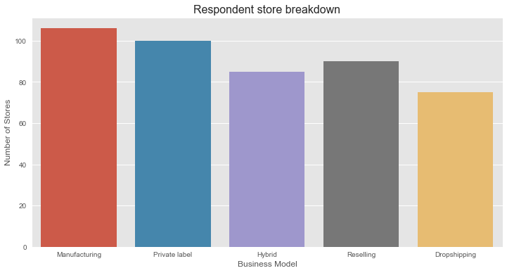

```python
fig, ax = plt.subplots(figsize=(12,6))
order = ['Manufacturing','Private label','Hybrid','Reselling','Dropshipping']
ax = sns.countplot(ax=ax, data=modified_results, x='Which model best describes your store type?', order=order)
plt.ylabel('Number of Stores')
plt.xlabel('Business Model')
plt.title('Respondent store breakdown', fontsize=16)
plt.tight_layout
plt.savefig('store_breakdown')
```

We have a pretty even split across each business model. First, let's compare each model on who their owners are. 95% confidence intervals are shown.

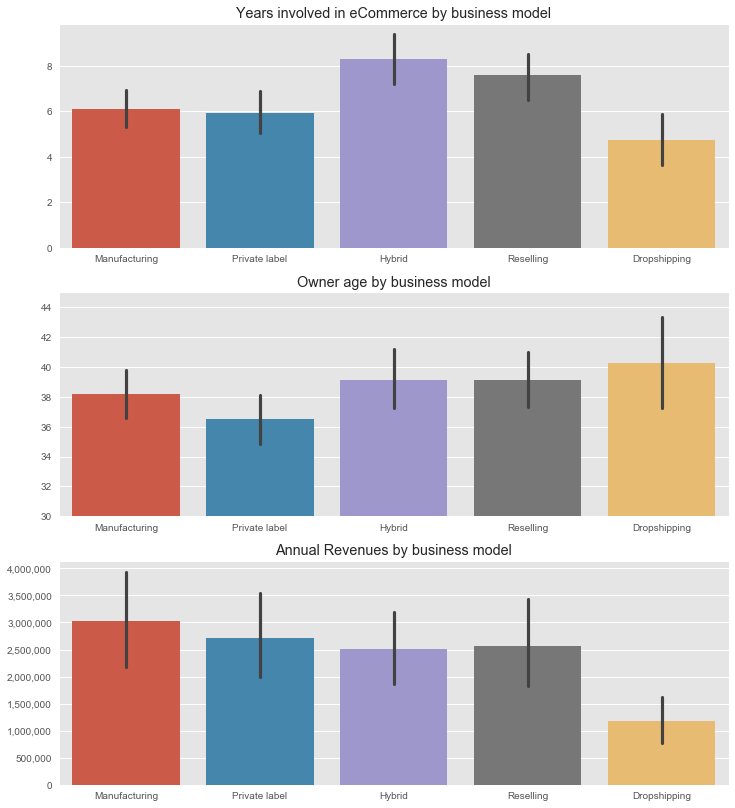

```python
import matplotlib.gridspec as gridspec
import matplotlib.ticker as ticker

#Create 2x2 subplots
gs = gridspec.GridSpec(3,1)

plt.figure(figsize=(12,14))
ax = plt.subplot(gs[0,0])
order = ['Manufacturing','Private label','Hybrid','Reselling','Dropshipping']
ax = sns.barplot(ax=ax, data=modified_results, x='Which model best describes your store type?', y='How many years have you been involved in eCommerce?', order=order)
plt.title('Years involved in eCommerce by business model')
plt.ylabel('')
plt.xlabel('')

ax = plt.subplot(gs[1,0])
ax = sns.barplot(ax=ax, data=modified_results, x='Which model best describes your store type?', y='How old are you?', order=order)
ax.set_ylim(30,45)
plt.title('Owner age by business model')
plt.ylabel('')
plt.xlabel('')

ax = plt.subplot(gs[2,0])
ax = sns.barplot(ax=ax, data=modified_results, x='Which model best describes your store type?', y='What are the annual revenues of your business?', order=order)
ax.get_yaxis().set_major_formatter(
    ticker.FuncFormatter(lambda x, p: format(int(x), ',')))
plt.title('Annual Revenues by business model')
plt.ylabel('')
plt.xlabel('')
plt.savefig('general_breakdown.png')
```

Drop-shipping has become increasingly popular over the past few years, and I expected drop-shippers to be younger and have less experience than the more traditional manufacturing model. Interestingly, we see that while drop-shippers tend to have less experience than owners of manufacturing businesses, the average age actually tends to be higher. Having said that, drop-shipping does have the greatest spread of owner ages, suggesting that it does have a lower barrier to entry and is easier for anyone to get involved with.

**One important number to take note of is the annual revenues by business model. Our drop-shippers in this survey average 2-2.5 times less revenue than other models, and this will be important to keep in mind when we start to look at some of the other statistics (such as total number of employees/contractors) in the next tables**

With that said, let's check out the averages across business models

```python
modified_results.groupby('Which model best describes your store type?').apply(np.mean).iloc[:,:16]
```

| Which model best describes your store type? | How many years have you been involved in eCommerce? | Excluding yourself, how many payrolled employees do you have? | How many contractors do you use in your business? | How many different SKUs do you sell? | How old are you? | How much do you struggle maintaining a work/life balance? | How many hours per week do you work? | Does your business provide a full-time income? Or, if you’re still working a job, could it? | What are the annual revenues of your business? | What is your average order value (AOV)? Please enter WITHOUT a "$" or currency sign. | Approximately how much did your revenue grow or shrink over the last year? | Approximately how much did your net income grow or shrink over the last year? | How much of an annual salary do you pay yourself? (A regular, recurring salary -- not business withdrawls or dividends) | What is your company’s approximate gross profit margin? (After paying product costs, but before fixed expenses.) | What is your company's approximate net profit margin? (Profits after paying all expenses and salaries, including your salary). | How much non-mortgage business related debt do you have? |
| --- | --- | --- | --- | --- | --- | --- | --- | --- | --- | --- | --- | --- | --- | --- | --- | --- |
| Dropshipping | 4.720000 | 2.113333 | 3.573333 | 6343.933333 | 40.233333 | 5.880000 | 43.493333 | 0.733333 | 1.177333e+06 | 405.440000 | 1.440000 | 1.427333 | 31326.666667 | 0.281667 | 0.136333 | 38600.000000 |
| Hybrid | 8.270588 | 6.358824 | 4.129412 | 4964.470588 | 39.147059 | 5.458824 | 49.994118 | 0.894118 | 2.502647e+06 | 176.494118 | 1.403529 | 1.348235 | 64094.117647 | 0.401765 | 0.167059 | 52294.117647 |
| Manufacturing | 6.099057 | 6.429245 | 4.754717 | 1356.367925 | 38.212264 | 5.320755 | 48.051887 | 0.867925 | 3.020047e+06 | 129.273585 | 1.533019 | 1.490094 | 67698.113208 | 0.485142 | 0.201179 | 55613.207547 |
| Private label | 5.915000 | 4.905000 | 3.890000 | 934.400000 | 36.520000 | 5.610000 | 44.295000 | 0.780000 | 2.721500e+06 | 124.880000 | 1.587000 | 1.538000 | 54065.000000 | 0.463500 | 0.208500 | 41975.000000 |
| Reselling | 7.566667 | 5.316667 | 2.333333 | 5405.333333 | 39.111111 | 5.088889 | 45.627778 | 0.822222 | 2.566389e+06 | 771.444444 | 1.317222 | 1.290000 | 63122.222222 | 0.343611 | 0.134167 | 43583.333333 |

```python
modified_results.groupby('Which model best describes your store type?').apply(np.mean).iloc[:,16:]
```

| Which model best describes your store type? | How much cash in terms of your ongoing business expenses do you keep in your business? | What is your average site-wide conversion rate? | Apart from Amazon, do you use a 3PL or fulfillment company to fulfill your orders? | Do you use your home as your primary office / work space? | What % of your sales come from Amazon? | Roughly how much have you seen your paid traffic costs per impression or CPA change this year? | What is your net worth excluding your eCommerce business' value? (Net worth: Value of all your assets minus debts) | Approximately what % of your net worth (excluding business value) is invested in the stock market? | Approximately what % of your net worth (excluding business value) is in cash? | Approximately what % of your net worth (excluding business value) is invested in real estate? | How much do you enjoy running / owning your business? | How hopeful are you for the future prospects of your business? | How happy overall would you say you are in life? | Are you a member of the eCommerceFuel Private Forum Community? | How would you rate the eCommerceFuel Private Community? | Employee to Contractor Ratio |
| --- | --- | --- | --- | --- | --- | --- | --- | --- | --- | --- | --- | --- | --- | --- | --- | --- |
| Dropshipping | 3.686667 | 0.017400 | 0.226667 | 0.746667 | 0.098000 | 1.108148 | 4.553800e+05 | 0.192667 | 0.285333 | 0.188667 | 8.053333 | 8.133333 | 8.026667 | 0.493333 | 8.567568 | 0.972032 |
| Hybrid | 5.194118 | 0.024794 | 0.176471 | 0.400000 | 0.221765 | 1.135410 | 1.191388e+06 | 0.246471 | 0.233529 | 0.292353 | 8.294118 | 8.094118 | 8.058824 | 0.752941 | 8.593750 | 2.672773 |
| Manufacturing | 6.726415 | 0.030896 | 0.386792 | 0.556604 | 0.270283 | 1.152771 | 9.990849e+05 | 0.218396 | 0.239151 | 0.293868 | 8.226415 | 8.377358 | 8.075472 | 0.679245 | 8.666667 | 2.090386 |
| Private label | 5.750000 | 0.029900 | 0.380000 | 0.570000 | 0.436750 | 1.142368 | 1.003130e+06 | 0.207500 | 0.277000 | 0.246000 | 7.940000 | 7.910000 | 7.920000 | 0.680000 | 8.485294 | 1.699643 |
| Reselling | 4.211111 | 0.026306 | 0.133333 | 0.377778 | 0.162778 | 1.162000 | 8.300444e+05 | 0.166667 | 0.189444 | 0.293889 | 8.311111 | 8.422222 | 7.966667 | 0.522222 | 8.787234 | 3.061111 |

Some interesting takeaways:

```python
modified_results['Which model best describes your store type?'].value_counts()
```

```
Manufacturing    106
Private label    100
Reselling         90
Hybrid            85
Dropshipping      75
Name: Which model best describes your store type?, dtype: int64
```

```python
modified_results.drop(223, axis=0).groupby('What are the annual revenues of your business?').apply(np.mean).iloc[:,:16]
```

| What are the annual revenues of your business? | How many years have you been involved in eCommerce? | Excluding yourself, how many payrolled employees do you have? | How many contractors do you use in your business? | How many different SKUs do you sell? | How old are you? | How much do you struggle maintaining a work/life balance? | How many hours per week do you work? | Does your business provide a full-time income? Or, if you’re still working a job, could it? | What are the annual revenues of your business? | What is your average order value (AOV)? Please enter WITHOUT a "$" or currency sign. | Approximately how much did your revenue grow or shrink over the last year? | Approximately how much did your net income grow or shrink over the last year? | How much of an annual salary do you pay yourself? (A regular, recurring salary -- not business withdrawls or dividends) | What is your company’s approximate gross profit margin? (After paying product costs, but before fixed expenses.) | What is your company's approximate net profit margin? (Profits after paying all expenses and salaries, including your salary). | How much non-mortgage business related debt do you have? |
| --- | --- | --- | --- | --- | --- | --- | --- | --- | --- | --- | --- | --- | --- | --- | --- | --- |
| 50000.0 | 2.433824 | 1.227941 | 2.029412 | 1449.264706 | 39.808824 | 6.264706 | 41.676471 | 0.338235 | 50000.0 | 321.205882 | 1.344853 | 1.247794 | 6970.588235 | 0.311397 | 0.169853 | 12500.000000 |
| 175000.0 | 5.085714 | 1.242857 | 2.342857 | 918.857143 | 36.957143 | 5.571429 | 48.600000 | 0.600000 | 175000.0 | 52.942857 | 1.420000 | 1.465714 | 18985.714286 | 0.432857 | 0.222857 | 11071.428571 |
| 375000.0 | 5.644068 | 1.381356 | 2.864407 | 1343.305085 | 37.279661 | 5.627119 | 46.864407 | 0.779661 | 375000.0 | 114.457627 | 1.467797 | 1.448305 | 37025.423729 | 0.443644 | 0.207627 | 24533.898305 |
| 750000.0 | 7.201299 | 2.623377 | 3.383117 | 2073.051948 | 39.909091 | 5.402597 | 45.383117 | 0.935065 | 750000.0 | 185.077922 | 1.541558 | 1.409740 | 43655.844156 | 0.416883 | 0.175974 | 34188.311688 |
| 1700000.0 | 7.677570 | 4.182243 | 4.088785 | 4481.308411 | 38.752336 | 5.009346 | 46.359813 | 0.962617 | 1700000.0 | 266.626168 | 1.422430 | 1.392056 | 66817.757009 | 0.417523 | 0.162850 | 42570.093458 |
| 3700000.0 | 8.291667 | 8.114583 | 4.812500 | 6001.979167 | 38.593750 | 4.916667 | 45.718750 | 1.000000 | 3700000.0 | 176.458333 | 1.527083 | 1.622917 | 88718.750000 | 0.423958 | 0.155208 | 97239.583333 |
| 7500000.0 | 8.093750 | 12.953125 | 6.812500 | 7876.093750 | 37.593750 | 5.593750 | 51.750000 | 1.000000 | 7500000.0 | 168.875000 | 1.693750 | 1.571875 | 116375.000000 | 0.410937 | 0.128125 | 135234.375000 |
| 15000000.0 | 8.879310 | 23.586207 | 6.293103 | 7995.689655 | 36.482759 | 5.620690 | 51.724138 | 1.000000 | 15000000.0 | 135.482759 | 1.365517 | 1.417241 | 145068.965517 | 0.384483 | 0.156034 | 85172.413793 |

```python
modified_results.groupby('What are the annual revenues of your business?').apply(np.mean).iloc[:,16:]
```

| What are the annual revenues of your business? | How much cash in terms of your ongoing business expenses do you keep in your business? | What is your average site-wide conversion rate? | Apart from Amazon, do you use a 3PL or fulfillment company to fulfill your orders? | Do you use your home as your primary office / work space? | What % of your sales come from Amazon? | Roughly how much have you seen your paid traffic costs per impression or CPA change this year? | What is your net worth excluding your eCommerce business' value? (Net worth: Value of all your assets minus debts) | Approximately what % of your net worth (excluding business value) is invested in the stock market? | Approximately what % of your net worth (excluding business value) is in cash? | Approximately what % of your net worth (excluding business value) is invested in real estate? | How much do you enjoy running / owning your business? | How hopeful are you for the future prospects of your business? | How happy overall would you say you are in life? | Are you a member of the eCommerceFuel Private Forum Community? | How would you rate the eCommerceFuel Private Community? | Employee to Contractor Ratio |
| --- | --- | --- | --- | --- | --- | --- | --- | --- | --- | --- | --- | --- | --- | --- | --- | --- |
| 50000.0 | 2.948529 | 0.017206 | 0.294118 | 0.911765 | 0.124265 | 1.192381 | 3.409412e+05 | 0.136765 | 0.249265 | 0.210294 | 7.941176 | 7.676471 | 7.500000 | 0.117647 | 8.625000 | 0.835084 |
| 175000.0 | 3.785714 | 0.034143 | 0.257143 | 0.857143 | 0.242857 | 1.193600 | 3.266571e+05 | 0.117143 | 0.218571 | 0.185714 | 8.342857 | 7.914286 | 7.771429 | 0.428571 | 8.400000 | 0.724490 |
| 375000.0 | 4.950000 | 0.022958 | 0.183333 | 0.766667 | 0.251250 | 1.150952 | 4.067500e+05 | 0.220000 | 0.245833 | 0.263333 | 8.366667 | 8.150000 | 7.850000 | 0.616667 | 8.837838 | 0.882143 |
| 750000.0 | 5.000000 | 0.028442 | 0.285714 | 0.506494 | 0.311688 | 1.130943 | 5.694740e+05 | 0.220130 | 0.238312 | 0.309091 | 7.857143 | 7.870130 | 8.090909 | 0.727273 | 9.017857 | 1.474150 |
| 1700000.0 | 6.495327 | 0.026215 | 0.261682 | 0.355140 | 0.247664 | 1.113882 | 8.667103e+05 | 0.202804 | 0.246729 | 0.273832 | 8.289720 | 8.588785 | 8.233645 | 0.803738 | 8.430233 | 1.993324 |
| 3700000.0 | 5.458333 | 0.027448 | 0.229167 | 0.333333 | 0.258333 | 1.158421 | 1.411938e+06 | 0.334375 | 0.238542 | 0.270833 | 8.229167 | 8.416667 | 8.125000 | 0.812500 | 8.666667 | 2.868254 |
| 7500000.0 | 6.078125 | 0.032578 | 0.343750 | 0.218750 | 0.350781 | 1.098462 | 1.716719e+06 | 0.215625 | 0.234375 | 0.345313 | 7.937500 | 8.593750 | 8.062500 | 0.750000 | 8.458333 | 4.487202 |
| 15000000.0 | 7.534483 | 0.032672 | 0.379310 | 0.068966 | 0.242241 | 1.124348 | 3.380138e+06 | 0.210345 | 0.286207 | 0.256897 | 8.551724 | 8.379310 | 8.517241 | 0.793103 | 8.173913 | 7.724138 |

```python
modified_results['What are the annual revenues of your business?'].value_counts()
```

```
1700000.0     107
750000.0       77
50000.0        68
375000.0       60
3700000.0      48
175000.0       35
7500000.0      32
15000000.0     29
Name: What are the annual revenues of your business?, dtype: int64
```

```python
modified_results[modified_results['What is your average order value (AOV)?  Please enter WITHOUT a "$" or currency sign.'] > 1000].drop(223, axis=0)
```

|  | Are you an eCommerce store owner or were you in the past 12 months? | Which model best describes your store type? | How many years have you been involved in eCommerce? | Excluding yourself, how many payrolled employees do you have? | How many contractors do you use in your business? | What category of products do you sell? | How many different SKUs do you sell? | How old are you? | What is your gender? | How much do you struggle maintaining a work/life balance? | ... | Approximately what % of your net worth (excluding business value) is in cash? | Approximately what % of your net worth (excluding business value) is invested in real estate? | How much do you enjoy running / owning your business? | How hopeful are you for the future prospects of your business? | How happy overall would you say you are in life? | What’s the biggest struggle you’re facing right now in your business? | Are you a member of the eCommerceFuel Private Forum Community? | How would you rate the eCommerceFuel Private Community? | Employee to Contractor Ratio | Happiness level |
| --- | --- | --- | --- | --- | --- | --- | --- | --- | --- | --- | --- | --- | --- | --- | --- | --- | --- | --- | --- | --- | --- |
| 18 | Yes | Manufacturing | 3.0 | 1.0 | 3.5 | Furniture | 55.0 | 34.5 | Male | 6.0 | ... | 0.40 | 0.6 | 9.0 | 8.0 | 10.0 | Manufacturing | 1.0 | 5.0 | 0.285714 | Very Happy (9-10) |
| 56 | Yes | Dropshipping | 4.0 | 30.0 | 30.0 | Clothing and Accessories - Women | 35000.0 | 34.5 | Male | 6.0 | ... | 0.00 | 0.0 | 9.0 | 9.0 | 9.0 | Conversion Rate | 0.0 | NaN | 1.000000 | Very Happy (9-10) |
| 181 | Yes | Dropshipping | 2.0 | 7.0 | 14.0 | Furniture | 17500.0 | 24.0 | Male | 7.0 | ... | 0.90 | 0.0 | 8.0 | 8.0 | 8.0 | Liquidating returned goods | 1.0 | 7.0 | 0.500000 | In the Middle (6-8) |
| 216 | Yes | Dropshipping | 6.0 | 30.0 | 0.0 | Arts and Crafts | 375.0 | 34.5 | Male | 6.0 | ... | 0.40 | 0.4 | 8.0 | 8.0 | 8.0 | information | 1.0 | 9.0 | 30.000000 | In the Middle (6-8) |
| 296 | Yes | Reselling | 3.0 | 3.5 | 0.0 | Industrial and Scientific | 775.0 | 44.5 | Male | 2.0 | ... | 0.05 | 0.2 | 9.0 | 9.0 | 9.0 | multiple projects/opportunities vs limited res... | 1.0 | 9.0 | 3.500000 | Very Happy (9-10) |
| 299 | Yes | Dropshipping | 17.0 | 7.0 | 7.0 | Home and Kitchen | 3000.0 | 44.5 | Male | 8.0 | ... | 0.00 | 0.0 | 9.0 | 9.0 | 7.0 | balancing resources to create growth | 0.0 | NaN | 1.000000 | In the Middle (6-8) |
| 327 | Yes | Private label | 17.0 | 1.0 | 3.5 | Patio, Lawn or Garden | 3000.0 | 34.5 | Male | 0.0 | ... | 0.20 | 0.0 | 8.0 | 8.0 | 10.0 | Minimizing outside factors that could hurt my ... | 1.0 | 8.0 | 0.285714 | Very Happy (9-10) |
| 352 | Yes | Dropshipping | 3.0 | 0.0 | 1.0 | Sports and Outdoors | 175.0 | 34.5 | Male | 1.0 | ... | 1.00 | 0.0 | 10.0 | 10.0 | 10.0 | Employees | 0.0 | NaN | 0.000000 | Very Happy (9-10) |
| 374 | Yes | Dropshipping | 0.5 | 0.0 | 0.0 | Sports and Outdoors | 55.0 | 44.5 | Male | 8.0 | ... | 0.10 | 0.4 | 8.0 | 8.0 | 9.0 | Conversions | 0.0 | NaN | 0.000000 | Very Happy (9-10) |
| 398 | Yes | Dropshipping | 8.0 | 0.0 | 7.0 | Industrial and Scientific | 3000.0 | 44.5 | Male | 5.0 | ... | 0.10 | 0.5 | 9.0 | 9.0 | 9.0 | Scaling up | 1.0 | 4.0 | 0.000000 | Very Happy (9-10) |
| 494 | Yes | Hybrid | 5.0 | 0.0 | 0.0 | Sports and Outdoors | 55.0 | 44.5 | Male | 1.0 | ... | 0.10 | 0.6 | 7.0 | 7.0 | 7.0 | Merchant account | 0.0 | NaN | 0.000000 | In the Middle (6-8) |
| 519 | Yes | Reselling | 1.0 | 1.0 | 3.5 | Shoes | 175.0 | 34.5 | Male | 7.0 | ... | 0.50 | 0.5 | 6.0 | 7.0 | 7.0 | Customers | 0.0 | NaN | 0.285714 | In the Middle (6-8) |

12 rows × 46 columns

#### Question: Do those who work from a home office struggle more with work:life balance? Do they work more or less hours and are they more satisfied?

```python
cols = ['Do you use your home as your primary office / work space?',
        'How many hours per week do you work?',
        'How much do you struggle maintaining a work/life balance?',
        'How happy overall would you say you are in life?']
modified_results[cols].groupby('Do you use your home as your primary office / work space?').apply(np.mean)
```

| Do you use your home as your primary office / work space? | Do you use your home as your primary office / work space? | How many hours per week do you work? | How much do you struggle maintaining a work/life balance? | How happy overall would you say you are in life? |
| --- | --- | --- | --- | --- |
| 0.0 | 0.0 | 49.307870 | 5.361111 | 8.180556 |
| 1.0 | 1.0 | 43.710417 | 5.541667 | 7.854167 |

Looks like those who work primarily from home struggle more with work:life balance despite working considerably fewer hours (perhaps they underestimate the true amount they work), and are less happy overall in life

#### Question: Did stores who reported higher increases in PPC costs also report less growth?

```python
modified_results[numeric_features].isnull().sum().sum()
```

```
0
```

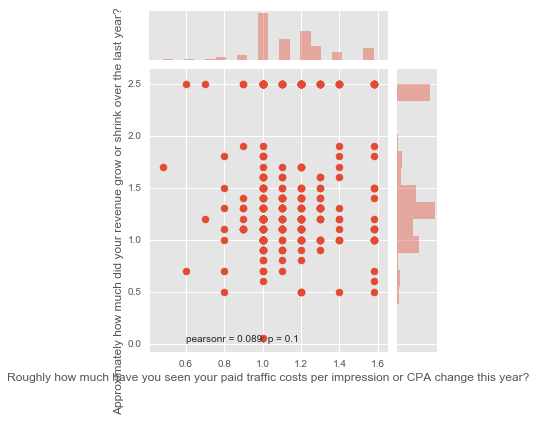

```python
sns.jointplot(data=modified_results[['Roughly how much have you seen your paid traffic costs per impression or CPA change this year?','Approximately how much did your revenue grow or shrink over the last year?']], x='Roughly how much have you seen your paid traffic costs per impression or CPA change this year?', y='Approximately how much did your revenue grow or shrink over the last year?')
```

Answer: No - in fact, those who reported higher PPC cost increases reported higher growth (although with only an ~8% correlation)

#### Question: How does an owner's years of eCommerce experience correlate with their current business' annual revenues?

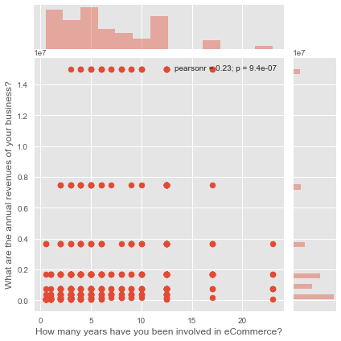

```python
sns.jointplot(data=modified_results, x='How many years have you been involved in eCommerce?', y='What are the annual revenues of your business?')
```

Looks like there is a mild correlation between years of experience and annual revenues, however after 4 years of experience, this difference becomes smaller

#### Question: Of stores where their website is their biggest channel, what is the difference in conversion rate between stores who have organic as their largest form of traffic vs PPC, email and the rest?

```python
modified_results[modified_results['What is your top sales channel?'] == 'My own website'].groupby('What is the biggest source of traffic to your website?').mean()['What is your average site-wide conversion rate?']
```

```
What is the biggest source of traffic to your website?
Direct                               0.041250
Email                                0.035938
Organic Search                       0.021656
Other                                0.017500
Paid Traffic                         0.024784
Referral (Links from Other Sites)    0.013500
Social (Non-Paid)                    0.019107
Name: What is your average site-wide conversion rate?, dtype: float64
```

#### Question: Let's take a look at Amazon-focused businesses vs non-Amazon businesses and compare them based on their growth rate, profit margins, PPC costs and optimism

```python
amazon_vs_rest = modified_results.copy()
amazon_vs_rest['amazon_focused'] = np.zeros(len(amazon_vs_rest))
for index in amazon_vs_rest.index.values:
    if amazon_vs_rest['What is your top sales channel?'][index] == 'Amazon':
        amazon_vs_rest['amazon_focused'][index] = 1
    elif amazon_vs_rest['What % of your sales come from Amazon?'][index] <= 0.3:
        amazon_vs_rest['amazon_focused'][index] = 2
```

```python
cols = [
    'Approximately how much did your revenue grow or shrink over the last year?',
    'What is your company’s approximate gross profit margin? (After paying product costs, but before fixed expenses.)',
    'What is your company\'s approximate net profit margin? (Profits after paying all expenses and salaries, including your salary).  ',
    'Roughly how much have you seen your paid traffic costs per impression or CPA change this year?',
    'How hopeful are you for the future prospects of your business?',
    'How much of an annual salary do you pay yourself?  (A regular, recurring salary -- not business withdrawls or dividends)',
    'What are the annual revenues of your business?'
]
amazon_vs_rest.groupby('amazon_focused')[cols].mean()
```

| amazon_focused | Approximately how much did your revenue grow or shrink over the last year? | What is your company’s approximate gross profit margin? (After paying product costs, but before fixed expenses.) | What is your company's approximate net profit margin? (Profits after paying all expenses and salaries, including your salary). | Roughly how much have you seen your paid traffic costs per impression or CPA change this year? | How hopeful are you for the future prospects of your business? | How much of an annual salary do you pay yourself? (A regular, recurring salary -- not business withdrawls or dividends) | What are the annual revenues of your business? |
| --- | --- | --- | --- | --- | --- | --- | --- |
| 0.0 | 1.588462 | 0.403846 | 0.176923 | 1.139000 | 7.769231 | 65288.461538 | 3.057692e+06 |
| 1.0 | 1.655462 | 0.368487 | 0.165336 | 1.165610 | 8.084034 | 62155.462185 | 2.611765e+06 |
| 2.0 | 1.378617 | 0.416801 | 0.174920 | 1.133448 | 8.266881 | 54556.270096 | 2.360048e+06 |

```python
amazon_vs_rest['What % of your sales come from Amazon?'].value_counts()
```

```
0.000    205
0.025     41
0.950     25
0.100     21
0.850     17
0.200     17
0.500     15
0.400     13
0.700     13
0.600     12
0.300     12
0.250     11
1.000     10
0.450      9
0.800      8
0.350      7
0.150      6
0.650      6
0.750      5
0.550      3
Name: What % of your sales come from Amazon?, dtype: int64
```

```python
amazon_vs_rest = modified_results.copy()
amazon_vs_rest['amazon_focused'] = np.zeros(len(amazon_vs_rest))
for index in amazon_vs_rest.index.values:
    if (amazon_vs_rest['What % of your sales come from Amazon?'][index] <= 0.1) & (amazon_vs_rest['What % of your sales come from Amazon?'][index] <= 0.3):
        amazon_vs_rest['amazon_focused'][index] = 1
    elif (amazon_vs_rest['What % of your sales come from Amazon?'][index] > 0.3) & (amazon_vs_rest['What % of your sales come from Amazon?'][index] < 0.7):
        amazon_vs_rest['amazon_focused'][index] = 2
    elif amazon_vs_rest['What % of your sales come from Amazon?'][index] >= 0.75:
        amazon_vs_rest['amazon_focused'][index] = 3
```

```python
cols = [
    'Approximately how much did your revenue grow or shrink over the last year?',
    'What is your company’s approximate gross profit margin? (After paying product costs, but before fixed expenses.)',
    'What is your company\'s approximate net profit margin? (Profits after paying all expenses and salaries, including your salary).  ',
    'Roughly how much have you seen your paid traffic costs per impression or CPA change this year?',
    'How hopeful are you for the future prospects of your business?',
    'How much of an annual salary do you pay yourself?  (A regular, recurring salary -- not business withdrawls or dividends)',
    'What are the annual revenues of your business?'
]
amazon_vs_rest.groupby('amazon_focused')[cols].mean()
```

| amazon_focused | Approximately how much did your revenue grow or shrink over the last year? | What is your company’s approximate gross profit margin? (After paying product costs, but before fixed expenses.) | What is your company's approximate net profit margin? (Profits after paying all expenses and salaries, including your salary). | Roughly how much have you seen your paid traffic costs per impression or CPA change this year? | How hopeful are you for the future prospects of your business? | How much of an annual salary do you pay yourself? (A regular, recurring salary -- not business withdrawls or dividends) | What are the annual revenues of your business? |
| --- | --- | --- | --- | --- | --- | --- | --- |
| 0.0 | 1.481356 | 0.439407 | 0.188136 | 1.167556 | 8.423729 | 67533.898305 | 3.575847e+06 |
| 1.0 | 1.375468 | 0.411236 | 0.171067 | 1.128020 | 8.247191 | 52458.801498 | 2.154588e+06 |
| 2.0 | 1.533846 | 0.375385 | 0.153077 | 1.151837 | 7.723077 | 66023.076923 | 2.865769e+06 |
| 3.0 | 1.733846 | 0.366923 | 0.183846 | 1.165581 | 8.215385 | 58130.769231 | 2.334615e+06 |

```python
amazon_vs_rest['amazon_focused'].value_counts()
```

```
1.0    267
2.0     65
3.0     65
0.0     59
Name: amazon_focused, dtype: int64
```

Here we can see a couple interesting things:

1. For Amazon sellers, the greater the portion of their revenue that comes from Amazon, the faster their revenues grew. Stores with 75%+ of revenue through Amazon grew by 73% - this is crazy, especially when the average revenue for these merchants is $2.33MM.
2. While Amazon sellers do see their gross profit margins decrease as they sell more through Amazon, this doesn't effect their net profit margin (after expenses). This suggests Amazon businesses have lower operating expenses, offsetting the higher competition in the Amazon marketplace (and additional fees).

#### Question: Who has the hardest time maintaining their work:life balance? Let's compare our respondants based on their marital status

```python
modified_results.groupby('What\'s your marital status?')['How old are you?','How much do you struggle maintaining a work/life balance?','How many hours per week do you work?','How much do you enjoy running / owning your business?','How happy overall would you say you are in life?','What is your net worth excluding your eCommerce business\' value? (Net worth:  Value of all your assets minus debts)'].mean()
```

| What's your marital status? | How old are you? | How much do you struggle maintaining a work/life balance? | How many hours per week do you work? | How much do you enjoy running / owning your business? | How happy overall would you say you are in life? | What is your net worth excluding your eCommerce business' value? (Net worth: Value of all your assets minus debts) |
| --- | --- | --- | --- | --- | --- | --- |
| Divorced | 46.807692 | 4.923077 | 43.192308 | 8.000000 | 8.076923 | 2.507692e+05 |
| Married | 40.256494 | 5.327922 | 46.613636 | 8.256494 | 8.178571 | 1.046333e+06 |
| Other | 34.868421 | 5.157895 | 36.473684 | 8.157895 | 7.631579 | 1.029368e+06 |
| Single | 32.814815 | 5.879630 | 48.013889 | 7.944444 | 7.583333 | 5.847778e+05 |
| Widowed | 59.125000 | 6.250000 | 40.500000 | 7.000000 | 7.750000 | 1.152500e+05 |

```python
modified_results['What\'s your marital status?'].value_counts()
```

```
Married     308
Single      108
Other        19
Divorced     13
Widowed       4
Name: What's your marital status?, dtype: int64
```

Looks like divorcees find their work:life balance the easiest compared to all other groups

#### Question: Let's take a look at ECF members. First off, are ECF members growing faster, are they happier, and are they more optimistic than non-members?

```python
modified_results.groupby('Are you a member of the eCommerceFuel Private Forum Community?').apply(np.mean).iloc[:,0:17]
```

| Are you a member of the eCommerceFuel Private Forum Community? | How many years have you been involved in eCommerce? | Excluding yourself, how many payrolled employees do you have? | How many contractors do you use in your business? | How many different SKUs do you sell? | How old are you? | How much do you struggle maintaining a work/life balance? | How many hours per week do you work? | Does your business provide a full-time income? Or, if you’re still working a job, could it? | What are the annual revenues of your business? | What is your average order value (AOV)? Please enter WITHOUT a "$" or currency sign. | Approximately how much did your revenue grow or shrink over the last year? | Approximately how much did your net income grow or shrink over the last year? | How much of an annual salary do you pay yourself? (A regular, recurring salary -- not business withdrawls or dividends) | What is your company’s approximate gross profit margin? (After paying product costs, but before fixed expenses.) | What is your company's approximate net profit margin? (Profits after paying all expenses and salaries, including your salary). | How much non-mortgage business related debt do you have? | How much cash in terms of your ongoing business expenses do you keep in your business? |
| --- | --- | --- | --- | --- | --- | --- | --- | --- | --- | --- | --- | --- | --- | --- | --- | --- | --- |
| 0.0 | 4.842262 | 3.327381 | 3.336310 | 2316.160714 | 38.675595 | 5.571429 | 46.520833 | 0.684524 | 1.487351e+06 | 503.232143 | 1.469345 | 1.411012 | 38494.047619 | 0.374554 | 0.183036 | 28020.833333 | 4.113095 |
| 1.0 | 7.508681 | 6.217014 | 4.032986 | 4279.010417 | 38.437500 | 5.388889 | 46.269097 | 0.902778 | 3.036111e+06 | 196.138889 | 1.459028 | 1.432118 | 68034.722222 | 0.420312 | 0.166406 | 57803.819444 | 5.881944 |

```python
modified_results.groupby('Are you a member of the eCommerceFuel Private Forum Community?').apply(np.mean).iloc[:,17:]
```

| Are you a member of the eCommerceFuel Private Forum Community? | What is your average site-wide conversion rate? | Apart from Amazon, do you use a 3PL or fulfillment company to fulfill your orders? | Do you use your home as your primary office / work space? | What % of your sales come from Amazon? | Roughly how much have you seen your paid traffic costs per impression or CPA change this year? | What is your net worth excluding your eCommerce business' value? (Net worth: Value of all your assets minus debts) | Approximately what % of your net worth (excluding business value) is invested in the stock market? | Approximately what % of your net worth (excluding business value) is in cash? | Approximately what % of your net worth (excluding business value) is invested in real estate? | How much do you enjoy running / owning your business? | How hopeful are you for the future prospects of your business? | How happy overall would you say you are in life? | Are you a member of the eCommerceFuel Private Forum Community? | How would you rate the eCommerceFuel Private Community? | Employee to Contractor Ratio |
| --- | --- | --- | --- | --- | --- | --- | --- | --- | --- | --- | --- | --- | --- | --- | --- |
| 0.0 | 0.026637 | 0.226190 | 0.636905 | 0.194792 | 1.165913 | 7.549107e+05 | 0.151786 | 0.252976 | 0.227679 | 8.196429 | 8.285714 | 7.922619 | 0.0 | NaN | 1.287528 |
| 1.0 | 0.026285 | 0.295139 | 0.461806 | 0.279340 | 1.128950 | 1.005266e+06 | 0.238889 | 0.239063 | 0.288021 | 8.145833 | 8.135417 | 8.059028 | 1.0 | 8.614583 | 2.607044 |

Here we see some key differences between groups: ECF members are 3 years more experienced, their stores earn twice as much, they pay themselves twice as much (and are much more likely to earn a full-time wage from their business) struggle less with work:life balance and are happier!

```python
ecf_cols = ['Are you a member of the eCommerceFuel Private Forum Community?',
            'How many years have you been involved in eCommerce?',
            'How old are you?',
            'What are the annual revenues of your business?',
            'How happy overall would you say you are in life?'

]

modified_results[ecf_cols].groupby('Are you a member of the eCommerceFuel Private Forum Community?').apply(np.mean)
```

| Are you a member of the eCommerceFuel Private Forum Community? | Are you a member of the eCommerceFuel Private Forum Community? | How many years have you been involved in eCommerce? | How old are you? | What are the annual revenues of your business? | How happy overall would you say you are in life? |
| --- | --- | --- | --- | --- | --- |
| 0.0 | 0.0 | 4.842262 | 38.675595 | 1.487351e+06 | 7.922619 |
| 1.0 | 1.0 | 7.508681 | 38.437500 | 3.036111e+06 | 8.059028 |

#### Now, let's look at some of the biggest struggles from all business

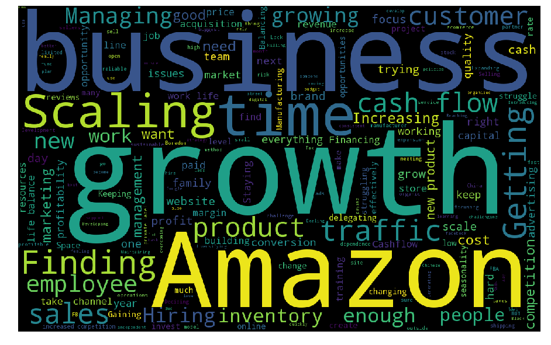

```python
from wordcloud import WordCloud
text = ' '.join(modified_results['What’s the biggest struggle you’re facing right now in your business?'].dropna())
wordcloud = WordCloud(width=1200,height=750).generate(text)
plt.figure(figsize=(16,12))
plt.imshow(wordcloud)
plt.axis('off')
plt.savefig('wordcloud.png')
```